# Scientific Advice

## Assessment

SCRS/2016/026 Cross testing of biodyn an R Package to Implement Management Procedures Based on Biomass Dynamic Models

SCRS/2016/027 Validation of biodyn, an R Package to Implement Management Procedures Based on Biomass Dynamic Models.

SCRS/2016/028 A Preliminary Stock Assessment for North Atlantic Albacore Using a Biomass Dynamic Model.

[output not shown]

## Kobe Framework

I have copied Haritz in hope you dont mind. I will also take all the points below and incorporate into a summary of the papers for the WG

On 15/04/16 09:56, Gorka Merino wrote: > > So, in the exercise evaluating HCRs that we presented in the WGSAM we had two main issues: CPUE and shape. With these papers we are showing that the results with a juvenile or total biomass CPUE are very similar, we can address the main concern from Craig. Yes, I said at WGSAM based on analysis was that Craigs concerns WRT indices, i.e. selection pattern and truncating the time series had been evaluated and shown not to be important. However, the shape of the production function was potentially important.

[output not shown]

> With the truncated time series issue, which I don’t think is a major issue in these results, although it could be for the coming assessment, we show that it is better to truncate than to not, which also addresses Michael’s comments.

[output not shown]

```
There are some important points WRT shape, that we still need to think about. i.e. thats why Craig and Michaels fixations were a cul-de-sac.
```

> In my opinion, although the convergence issues in the biodyn fits done in that framework, and with aspic in 2013, the paper we presented in the WGSAM, and the results, may be refined but not completely thrashed. Haritz has asked if I planned to make some changes as suggested by the WGSAM, remove it or rewrite it. According to papers 24-27, the two major concers (CPUE and shape) may not be that relevant. Morevoer, if the papers demonstrate that using the truncated time series was a good decision. I would prefer to make some additions (runs with different shapes) or something else but not change completely or remove. What do you think?

```
The problem with the 2013 ASPIC was non convergence and instability due to use of LAV
```

> With regards to the new assessment, yes, if we finally get it, that would be great and hopefully incorporated in the new MSE, may be for another paper.

## OM

SCRS/2016/023 Conditioning An Operating Model For North Atlantic Albacore.

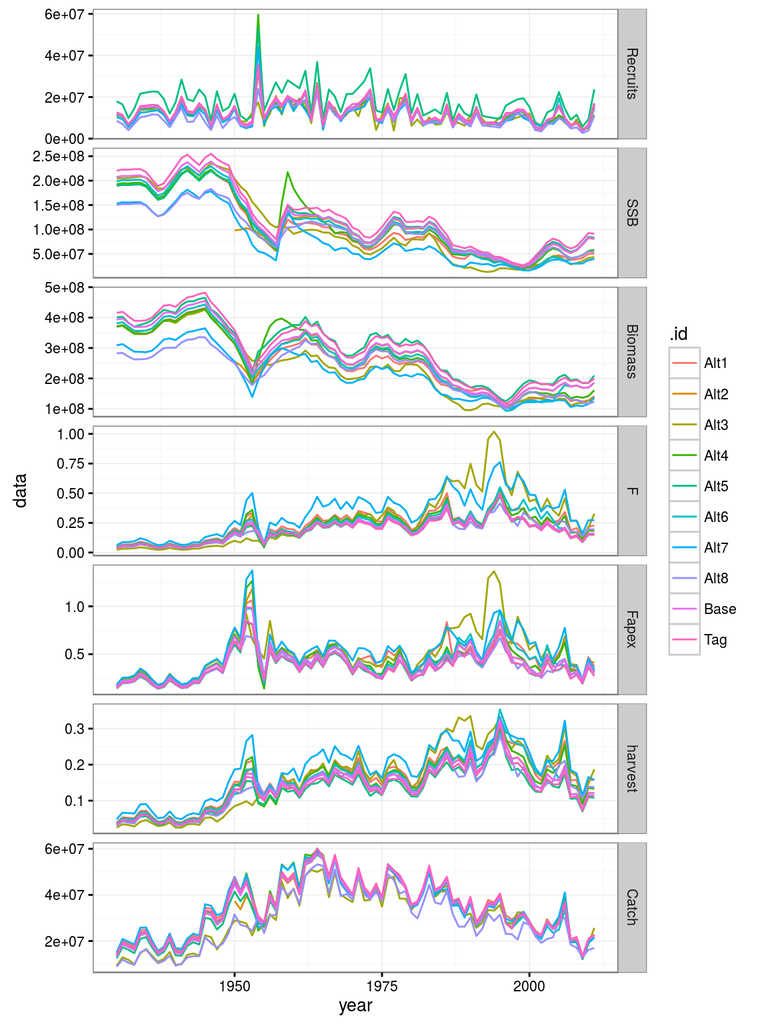

OMs

## OEM

SCRS/2016/024 An Observation Error Model For North Atlantic Albacore.

## MP

SCRS/2016/025 The Implicit North Atlantic Albacore Management Procedure.